# Ch6

CZH

2024-07-06

## Test Case: Birth weight data

Included in R already:

```r
library(tidyverse)
library(lubridate)
library(MASS)
library(conflicted)
data(birthwt)
summary(birthwt)
```

```
##       low              age             lwt             race
##  Min.   :0.0000   Min.   :14.00   Min.   : 80.0   Min.   :1.000
##  1st Qu.:0.0000   1st Qu.:19.00   1st Qu.:110.0   1st Qu.:1.000
##  Median :0.0000   Median :23.00   Median :121.0   Median :1.000
##  Mean   :0.3122   Mean   :23.24   Mean   :129.8   Mean   :1.847
##  3rd Qu.:1.0000   3rd Qu.:26.00   3rd Qu.:140.0   3rd Qu.:3.000
##  Max.   :1.0000   Max.   :45.00   Max.   :250.0   Max.   :3.000
##      smoke             ptl               ht                ui
##  Min.   :0.0000   Min.   :0.0000   Min.   :0.00000   Min.   :0.0000
##  1st Qu.:0.0000   1st Qu.:0.0000   1st Qu.:0.00000   1st Qu.:0.0000
##  Median :0.0000   Median :0.0000   Median :0.00000   Median :0.0000
##  Mean   :0.3915   Mean   :0.1958   Mean   :0.06349   Mean   :0.1481
##  3rd Qu.:1.0000   3rd Qu.:0.0000   3rd Qu.:0.00000   3rd Qu.:0.0000
##  Max.   :1.0000   Max.   :3.0000   Max.   :1.00000   Max.   :1.0000
##       ftv              bwt
##  Min.   :0.0000   Min.   : 709
##  1st Qu.:0.0000   1st Qu.:2414
##  Median :0.0000   Median :2977
##  Mean   :0.7937   Mean   :2945
##  3rd Qu.:1.0000   3rd Qu.:3487
##  Max.   :6.0000   Max.   :4990
```

#### Make it readable!

```r
colnames(birthwt)
```

```
##  [1] "low"   "age"   "lwt"   "race"  "smoke" "ptl"   "ht"    "ui"    "ftv"
## [10] "bwt"
```

```r
colnames(birthwt) <- c("birthwt.below.2500", "mother.age",
                       "mother.weight", "race",
                       "mother.smokes", "previous.prem.labor",
                       "hypertension", "uterine.irr",
                       "physician.visits", "birthwt.grams")
```

Let’s make all the factors more descriptive.

```r
birthwt$race <- factor(c("white", "black", "other")[birthwt$race])
birthwt$mother.smokes <- factor(c("No", "Yes")[birthwt$mother.smokes + 1])
birthwt$uterine.irr <- factor(c("No", "Yes")[birthwt$uterine.irr + 1])
birthwt$hypertension <- factor(c("No", "Yes")[birthwt$hypertension + 1])
```

#### Bar plot for race

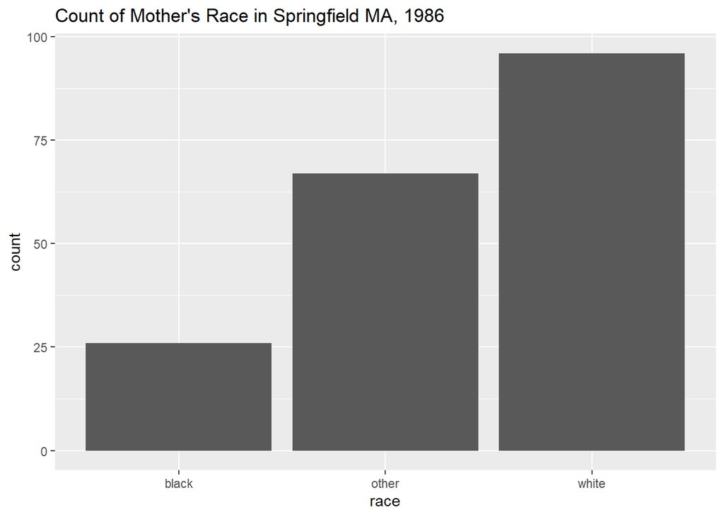

```r
birthwt |> ggplot(aes(x = race))+
  geom_bar()+
  labs(title = "Count of Mother's Race in Springfield MA, 1986")
```

#### Scatter plot for mother’s ages

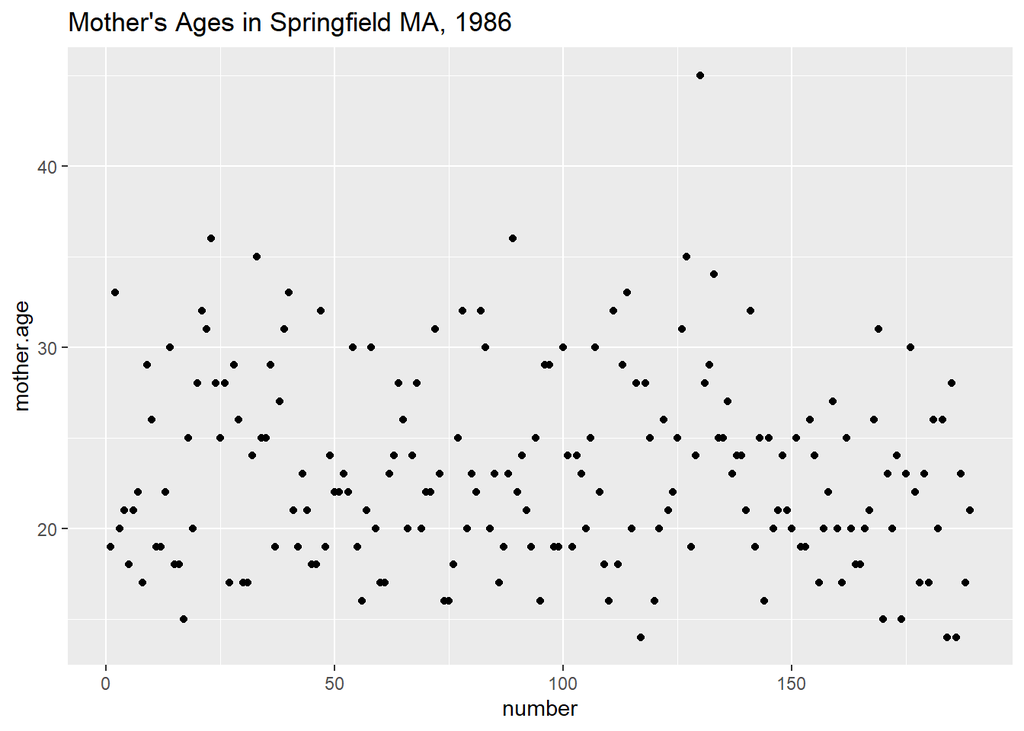

```r
birthwt |> ggplot(aes(x = 1:nrow(birthwt), y = mother.age))+
  geom_point()+
  labs(x = 'number', title = "Mother's Ages in Springfield MA, 1986")
```

#### Sorted mother’s ages

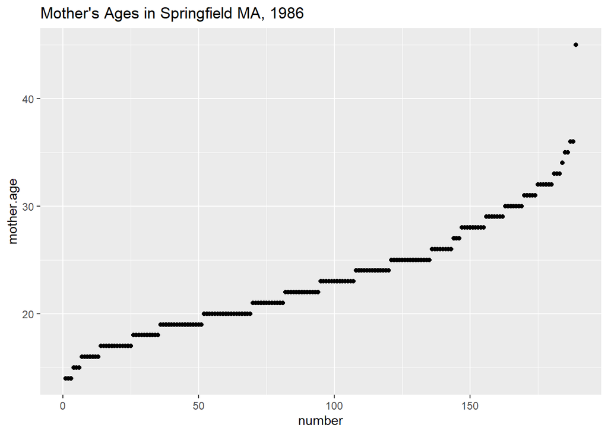

```r
birthwt |> arrange(mother.age) |> ggplot(aes(x = 1:nrow(birthwt), y = mother.age))+
  geom_point()+
  labs(x = 'number', title = "Mother's Ages in Springfield MA, 1986")
```

#### Birth weight versus mother’s ages

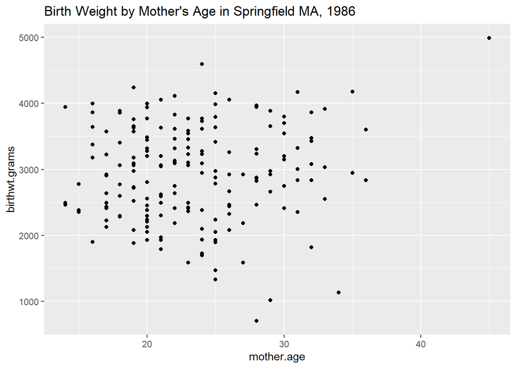

```r
birthwt |> ggplot(aes(x = mother.age, y = birthwt.grams))+
  geom_point()+
  labs(title = "Birth Weight by Mother's Age in Springfield MA, 1986")
```

#### Boxplot Let’s fit some models to the data pertaining to our outcome(s) of interest.

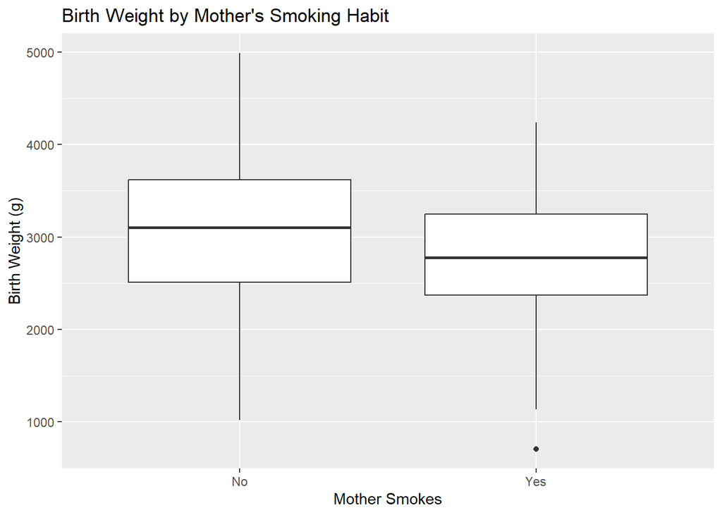

```r
birthwt |> ggplot(aes(x = mother.smokes, y = birthwt.grams))+
  geom_boxplot()+
  labs(title = "Birth Weight by Mother's Smoking Habit", y = "Birth Weight (g)", x="Mother Smokes")
```

#### Basic statistical testing

```r
t.test (birthwt$birthwt.grams[birthwt$mother.smokes == "Yes"],
        birthwt$birthwt.grams[birthwt$mother.smokes == "No"], var.equal = T)
```

```
##
##  Two Sample t-test
##
## data:  birthwt$birthwt.grams[birthwt$mother.smokes == "Yes"] and birthwt$birthwt.grams[birthwt$mother.smokes == "No"]
## t = -2.6529, df = 187, p-value = 0.008667
## alternative hypothesis: true difference in means is not equal to 0
## 95 percent confidence interval:
##  -494.79735  -72.75612
## sample estimates:
## mean of x mean of y
##  2771.919  3055.696
```

Does this difference match the linear model?

```r
linear.model.1 <- lm (birthwt.grams ~ mother.smokes, data=birthwt)
summary(linear.model.1)
```

```
##
## Call:
## lm(formula = birthwt.grams ~ mother.smokes, data = birthwt)
##
## Residuals:
##     Min      1Q  Median      3Q     Max
## -2062.9  -475.9    34.3   545.1  1934.3
##
## Coefficients:
##                  Estimate Std. Error t value Pr(>|t|)
## (Intercept)       3055.70      66.93  45.653  < 2e-16 ***
## mother.smokesYes  -283.78     106.97  -2.653  0.00867 **
## ---
## Signif. codes:  0 '***' 0.001 '**' 0.01 '*' 0.05 '.' 0.1 ' ' 1
##
## Residual standard error: 717.8 on 187 degrees of freedom
## Multiple R-squared:  0.03627,    Adjusted R-squared:  0.03112
## F-statistic: 7.038 on 1 and 187 DF,  p-value: 0.008667
```

```r
linear.model.2 <- lm (birthwt.grams ~ mother.age, data=birthwt)
summary(linear.model.2)
```

```
##
## Call:
## lm(formula = birthwt.grams ~ mother.age, data = birthwt)
##
## Residuals:
##      Min       1Q   Median       3Q      Max
## -2294.78  -517.63    10.51   530.80  1774.92
##
## Coefficients:
##             Estimate Std. Error t value Pr(>|t|)
## (Intercept)  2655.74     238.86   11.12   <2e-16 ***
## mother.age     12.43      10.02    1.24    0.216
## ---
## Signif. codes:  0 '***' 0.001 '**' 0.01 '*' 0.05 '.' 0.1 ' ' 1
##
## Residual standard error: 728.2 on 187 degrees of freedom
## Multiple R-squared:  0.008157,   Adjusted R-squared:  0.002853
## F-statistic: 1.538 on 1 and 187 DF,  p-value: 0.2165
```

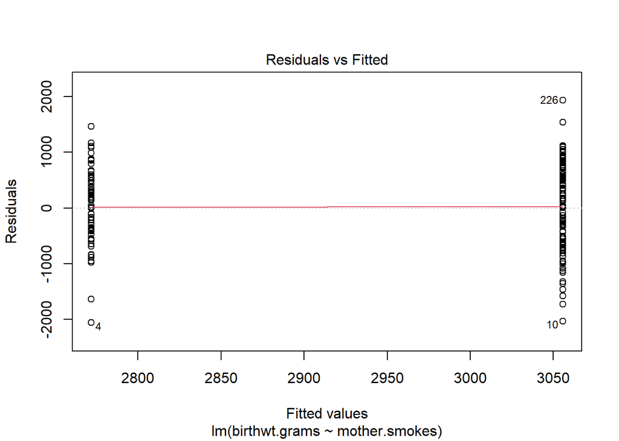

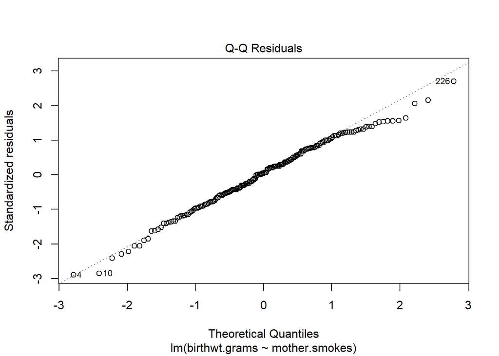

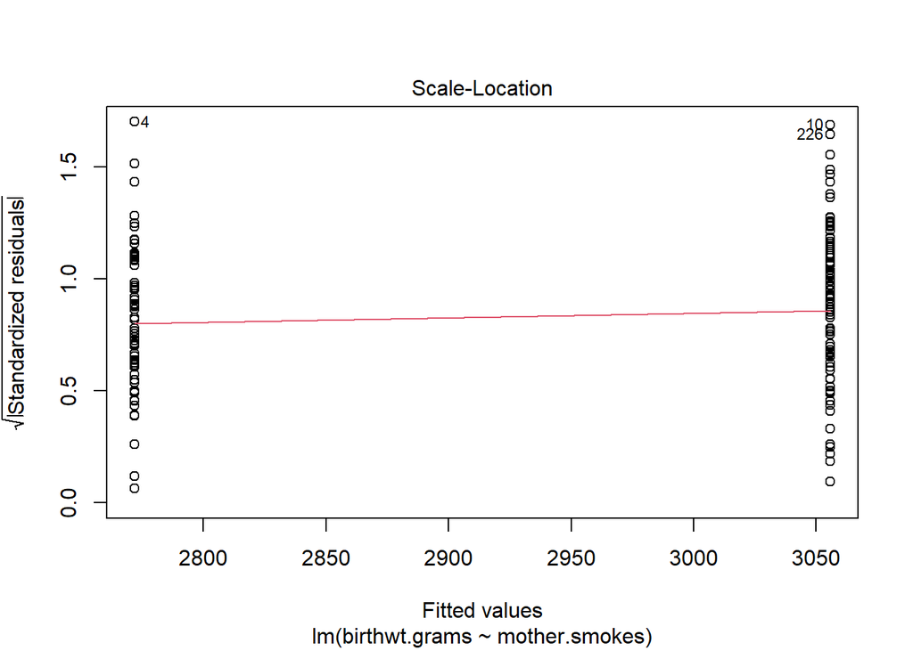

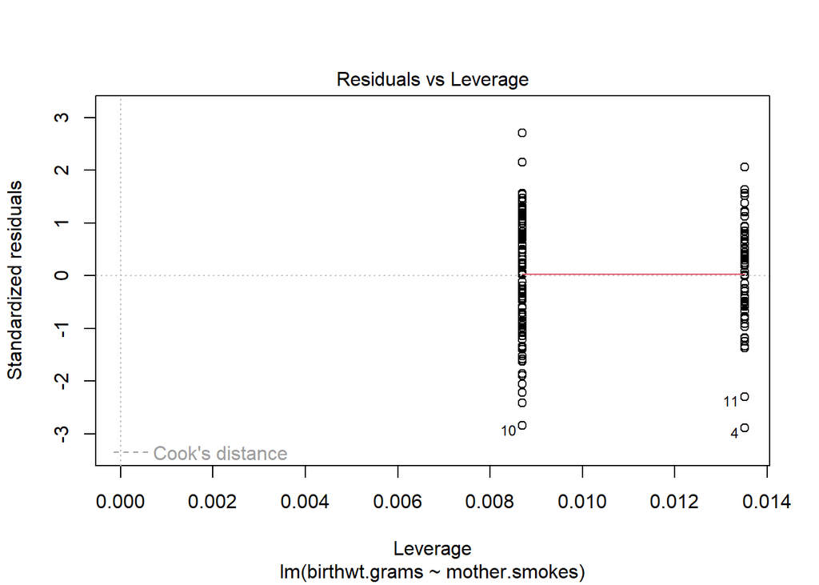

```r
plot(linear.model.1)
```

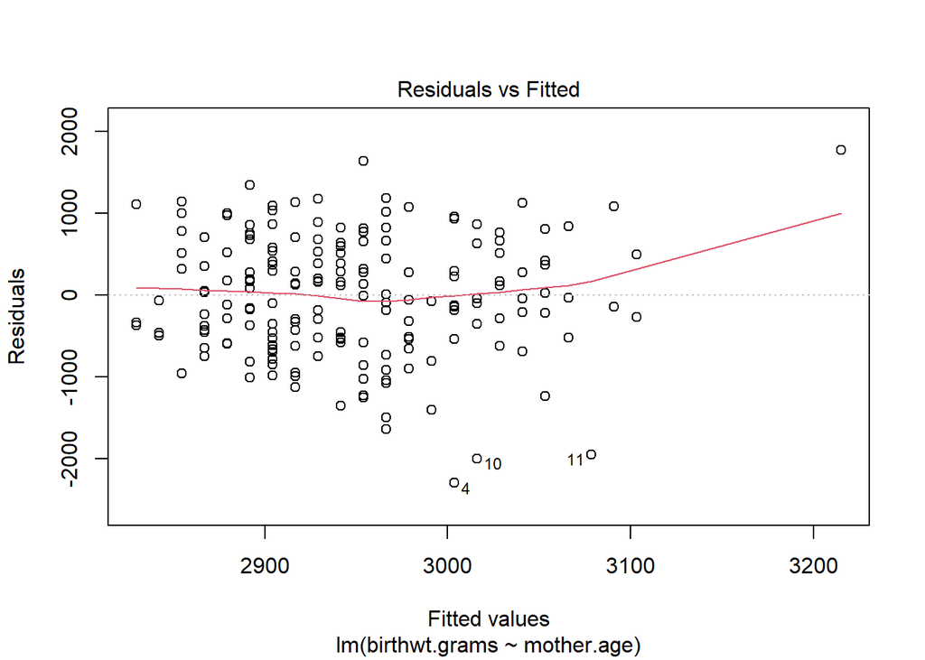

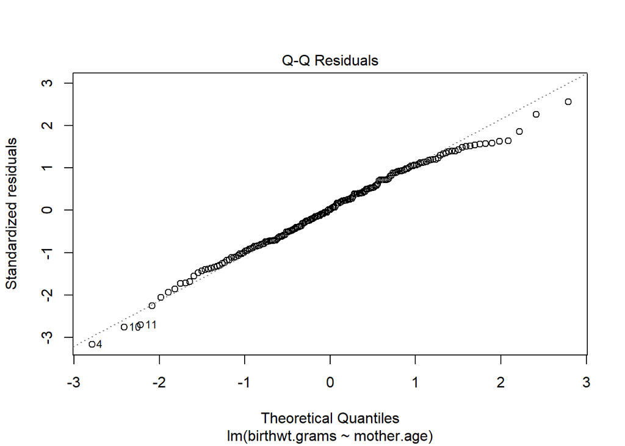

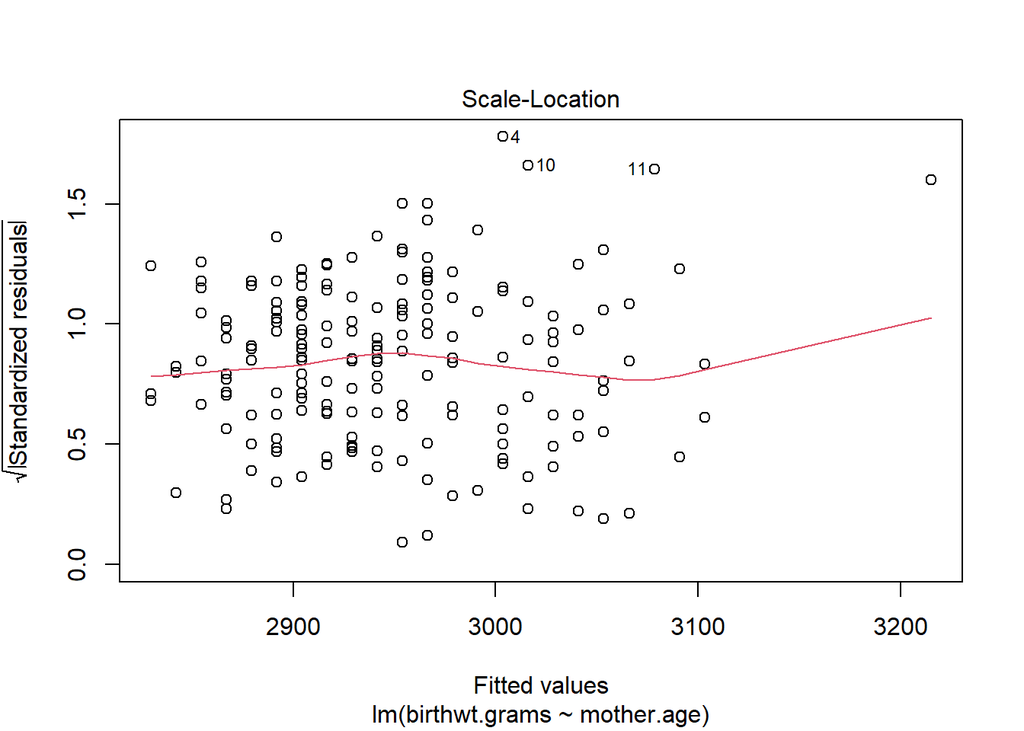

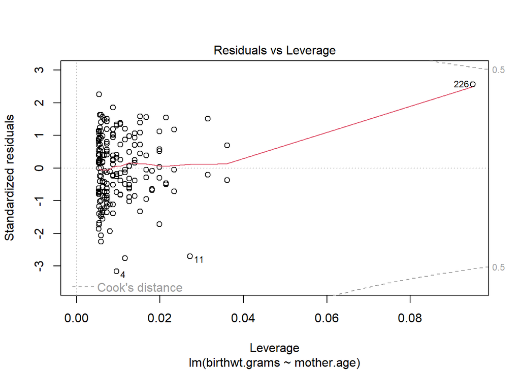

```r
plot(linear.model.2)
```

#### Detecting Outliers

These are the default diagnostic plots for the analysis. Note that our oldest mother and her heaviest child are greatly skewing this analysis as we suspected.

```r
birthwt.noout <- birthwt |> dplyr::filter(mother.age <= 40)
linear.model.3 <- lm (birthwt.grams ~ mother.age, data=birthwt.noout)
summary(linear.model.3)
```

```
##
## Call:
## lm(formula = birthwt.grams ~ mother.age, data = birthwt.noout)
##
## Residuals:
##      Min       1Q   Median       3Q      Max
## -2245.89  -511.24    26.45   540.09  1655.48
##
## Coefficients:
##             Estimate Std. Error t value Pr(>|t|)
## (Intercept) 2833.273    244.954   11.57   <2e-16 ***
## mother.age     4.344     10.349    0.42    0.675
## ---
## Signif. codes:  0 '***' 0.001 '**' 0.01 '*' 0.05 '.' 0.1 ' ' 1
##
## Residual standard error: 717.2 on 186 degrees of freedom
## Multiple R-squared:  0.0009461,  Adjusted R-squared:  -0.004425
## F-statistic: 0.1761 on 1 and 186 DF,  p-value: 0.6752
```

#### More complex models

Add in smoking behavior:

```r
linear.model.3a <- lm (birthwt.grams ~ + mother.smokes + mother.age, data=birthwt.noout)
summary(linear.model.3a)
```

```
##
## Call:
## lm(formula = birthwt.grams ~ +mother.smokes + mother.age, data = birthwt.noout)
##
## Residuals:
##      Min       1Q   Median       3Q      Max
## -2081.22  -459.82    43.56   548.22  1551.51
##
## Coefficients:
##                  Estimate Std. Error t value Pr(>|t|)
## (Intercept)      2954.582    246.280  11.997   <2e-16 ***
## mother.smokesYes -265.756    105.605  -2.517   0.0127 *
## mother.age          3.621     10.208   0.355   0.7232
## ---
## Signif. codes:  0 '***' 0.001 '**' 0.01 '*' 0.05 '.' 0.1 ' ' 1
##
## Residual standard error: 707.1 on 185 degrees of freedom
## Multiple R-squared:  0.03401,    Adjusted R-squared:  0.02357
## F-statistic: 3.257 on 2 and 185 DF,  p-value: 0.04072
```

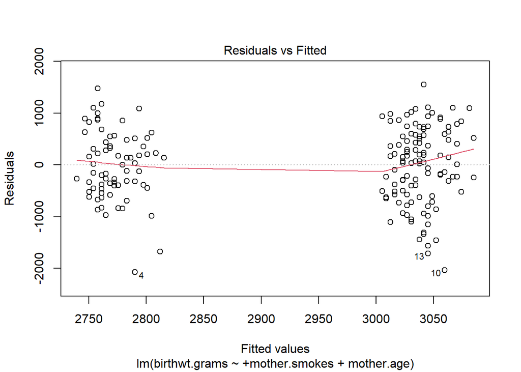

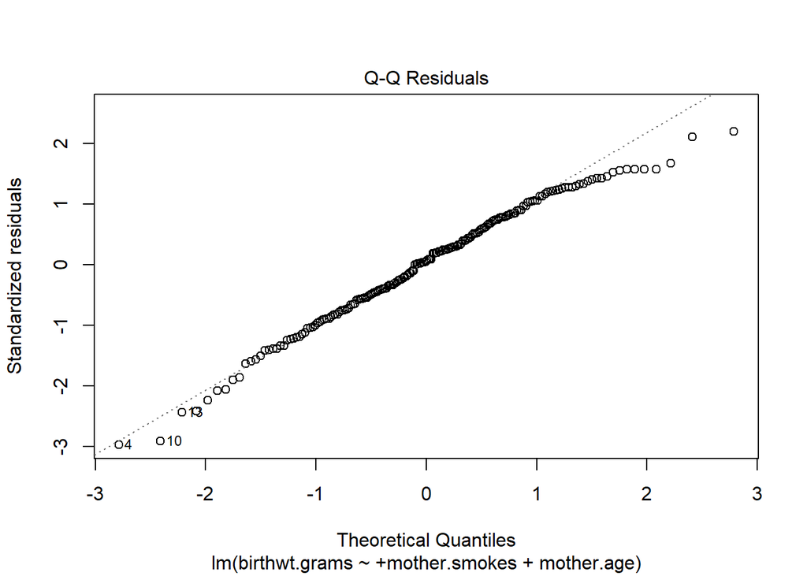

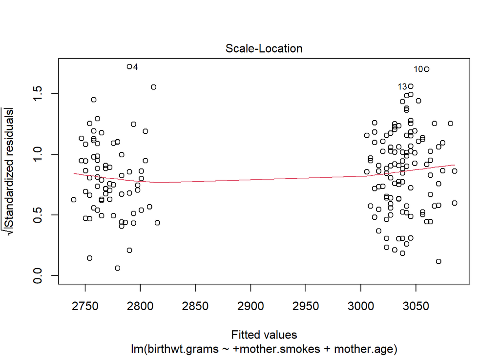

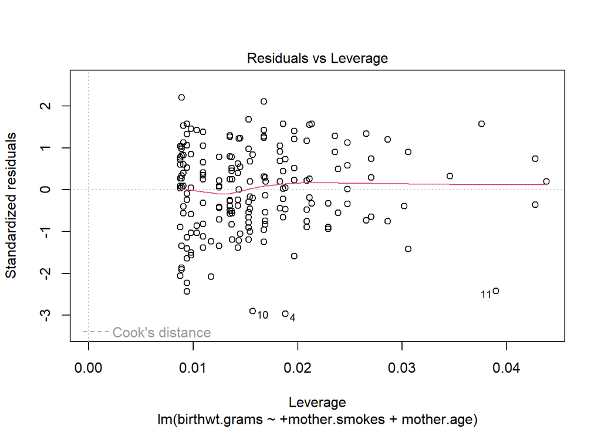

```r
plot(linear.model.3a)
```

```r
linear.model.3b <- lm (birthwt.grams ~ mother.age + mother.smokes + race, data=birthwt.noout)
summary(linear.model.3b)
```

```
##
## Call:
## lm(formula = birthwt.grams ~ mother.age + mother.smokes + race,
##     data = birthwt.noout)
##
## Residuals:
##      Min       1Q   Median       3Q      Max
## -2261.76  -422.49    15.98   512.00  1315.40
##
## Coefficients:
##                  Estimate Std. Error t value Pr(>|t|)
## (Intercept)      2986.405    260.897  11.447  < 2e-16 ***
## mother.age         -5.050     10.056  -0.502 0.616136
## mother.smokesYes -410.656    108.635  -3.780 0.000212 ***
## raceother           5.487    158.918   0.035 0.972492
## racewhite         442.799    154.023   2.875 0.004521 **
## ---
## Signif. codes:  0 '***' 0.001 '**' 0.01 '*' 0.05 '.' 0.1 ' ' 1
##
## Residual standard error: 680.4 on 183 degrees of freedom
## Multiple R-squared:  0.1153, Adjusted R-squared:  0.09592
## F-statistic:  5.96 on 4 and 183 DF,  p-value: 0.000157
```

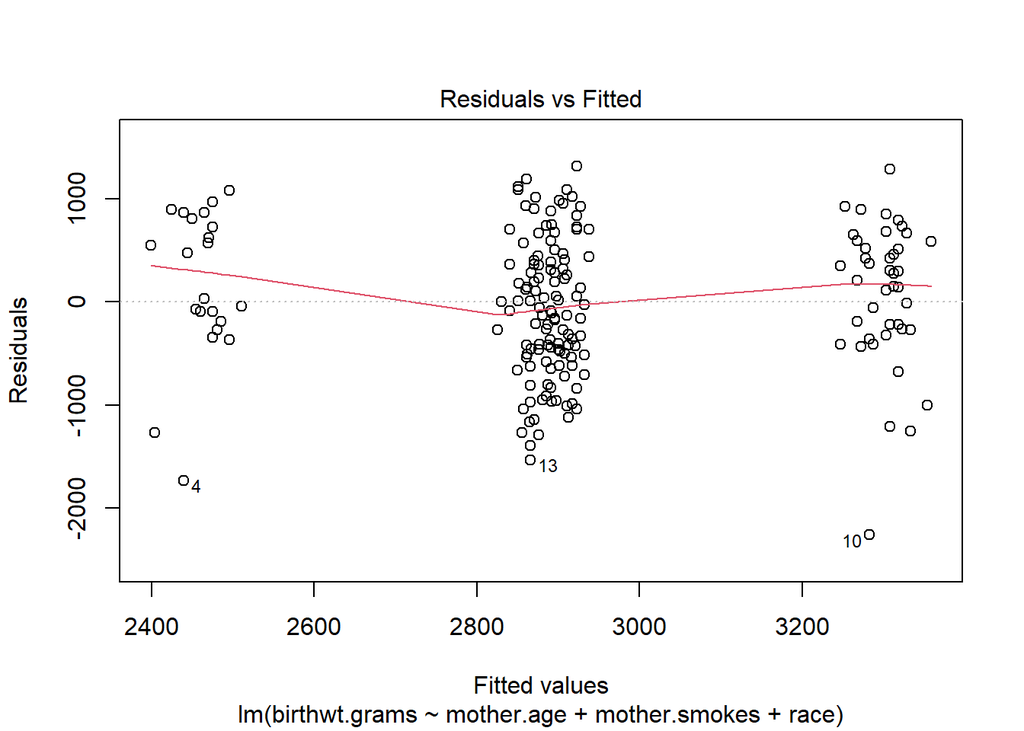

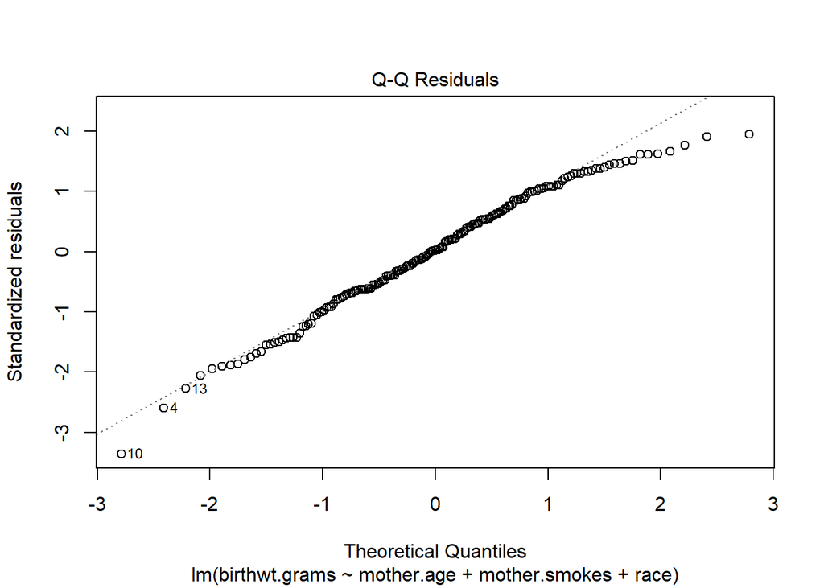

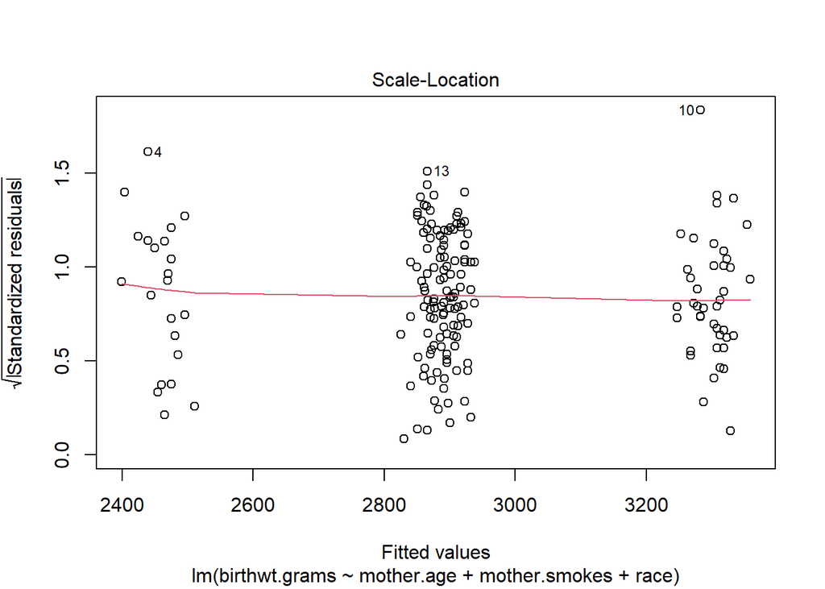

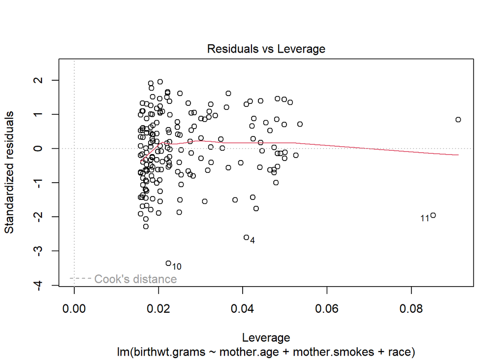

```r
plot(linear.model.3b)
```

#### Everything Must Go (In)

```r
linear.model.4 <- lm (birthwt.grams ~ ., data=birthwt.noout)
summary(linear.model.4)
```

```
##
## Call:
## lm(formula = birthwt.grams ~ ., data = birthwt.noout)
##
## Residuals:
##     Min      1Q  Median      3Q     Max
## -985.04 -274.13  -13.87  262.53 1146.50
##
## Coefficients:
##                       Estimate Std. Error t value Pr(>|t|)
## (Intercept)          3360.5163   215.4112  15.600  < 2e-16 ***
## birthwt.below.2500  -1116.3933    70.8578 -15.755  < 2e-16 ***
## mother.age            -16.0321     6.4159  -2.499 0.013373 *
## mother.weight           1.9317     1.1208   1.723 0.086545 .
## raceother              68.8145   101.4451   0.678 0.498441
## racewhite             247.0241    96.4935   2.560 0.011302 *
## mother.smokesYes     -157.7041    68.6205  -2.298 0.022719 *
## previous.prem.labor    95.9825    65.3329   1.469 0.143573
## hypertensionYes      -185.2778   131.0126  -1.414 0.159060
## uterine.irrYes       -340.0918    88.8465  -3.828 0.000179 ***
## physician.visits       -0.3519    29.5378  -0.012 0.990509
## ---
## Signif. codes:  0 '***' 0.001 '**' 0.01 '*' 0.05 '.' 0.1 ' ' 1
##
## Residual standard error: 412.8 on 177 degrees of freedom
## Multiple R-squared:  0.6851, Adjusted R-squared:  0.6673
## F-statistic: 38.51 on 10 and 177 DF,  p-value: < 2.2e-16
```

#### Everything Must Go (In), Except What Must Not

One of those variables was birthwt.below.2500 which is a function of the outcome.

```r
linear.model.4a <- lm (birthwt.grams ~ . - birthwt.below.2500, data=birthwt.noout)
summary(linear.model.4a)
```

```
##
## Call:
## lm(formula = birthwt.grams ~ . - birthwt.below.2500, data = birthwt.noout)
##
## Residuals:
##      Min       1Q   Median       3Q      Max
## -1761.10  -454.81    46.43   459.78  1394.13
##
## Coefficients:
##                     Estimate Std. Error t value Pr(>|t|)
## (Intercept)         2545.584    323.204   7.876 3.21e-13 ***
## mother.age           -12.111      9.909  -1.222 0.223243
## mother.weight          4.789      1.710   2.801 0.005656 **
## raceother            155.605    156.564   0.994 0.321634
## racewhite            494.545    147.153   3.361 0.000951 ***
## mother.smokesYes    -335.793    104.613  -3.210 0.001576 **
## previous.prem.labor  -32.922    100.185  -0.329 0.742838
## hypertensionYes     -594.324    198.480  -2.994 0.003142 **
## uterine.irrYes      -514.842    136.249  -3.779 0.000215 ***
## physician.visits      -7.247     45.649  -0.159 0.874036
## ---
## Signif. codes:  0 '***' 0.001 '**' 0.01 '*' 0.05 '.' 0.1 ' ' 1
##
## Residual standard error: 638 on 178 degrees of freedom
## Multiple R-squared:  0.2435, Adjusted R-squared:  0.2052
## F-statistic: 6.365 on 9 and 178 DF,  p-value: 8.255e-08
```

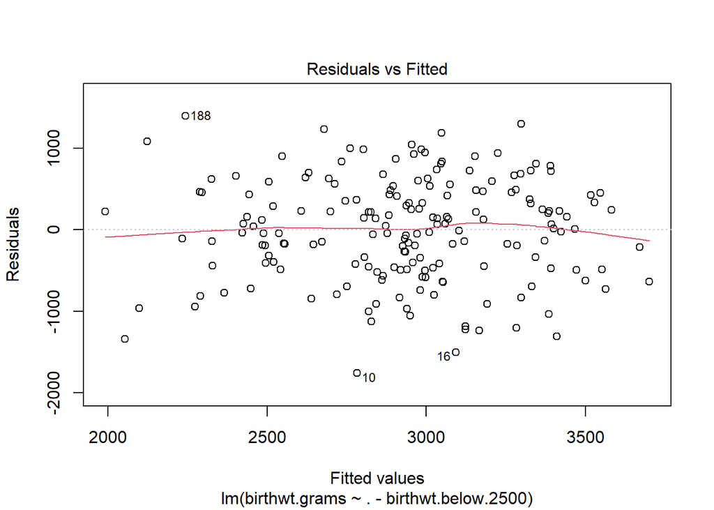

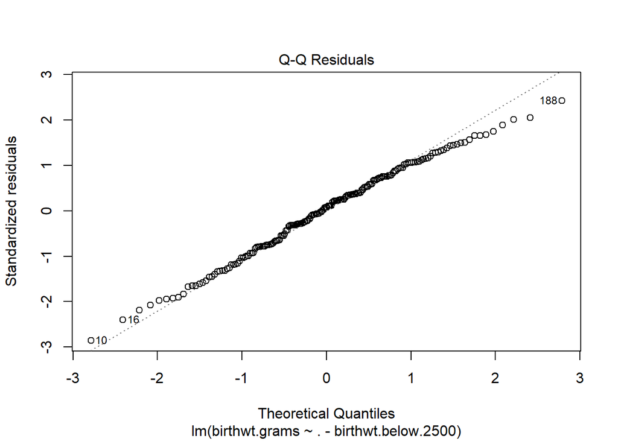

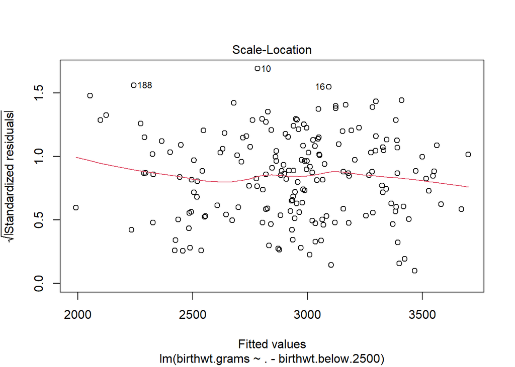

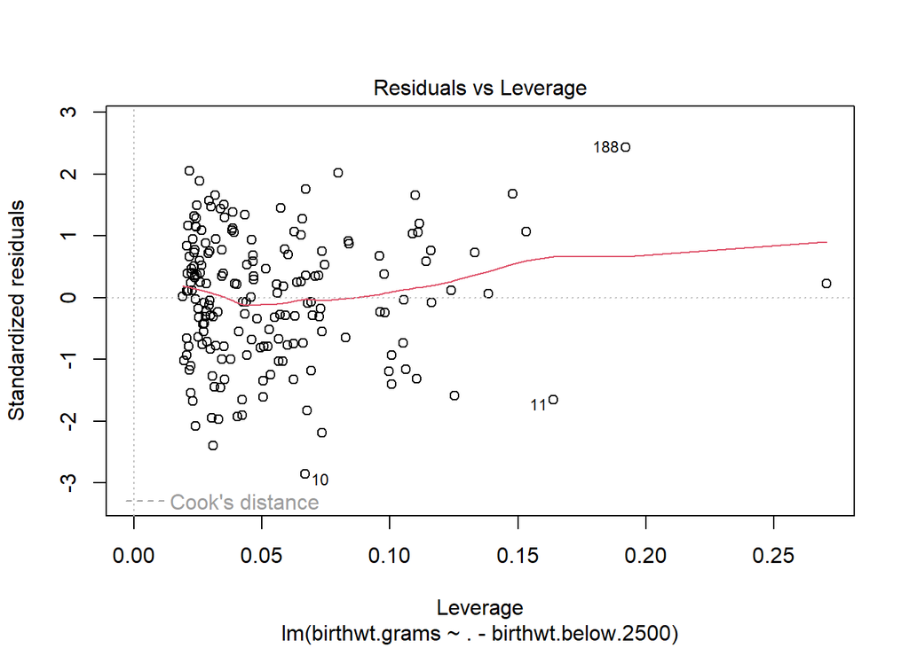

```r
plot(linear.model.4a)
```

#### Generalized Linear Models

Maybe a linear increase in birth weight is less important than if it’s below a threshold like 2500 grams (5.5 pounds). Let’s fit a generalized linear model instead:

```r
glm.0 <- glm (birthwt.below.2500 ~ . - birthwt.grams, data=birthwt.noout)
summary(glm.0)
```

```
##
## Call:
## glm(formula = birthwt.below.2500 ~ . - birthwt.grams, data = birthwt.noout)
##
## Coefficients:
##                      Estimate Std. Error t value Pr(>|t|)
## (Intercept)          0.729969   0.221195   3.300  0.00117 **
## mother.age          -0.003512   0.006782  -0.518  0.60517
## mother.weight       -0.002559   0.001170  -2.187  0.03003 *
## raceother           -0.077742   0.107150  -0.726  0.46907
## racewhite           -0.221715   0.100709  -2.202  0.02898 *
## mother.smokesYes     0.159522   0.071595   2.228  0.02713 *
## previous.prem.labor  0.115465   0.068565   1.684  0.09393 .
## hypertensionYes      0.366400   0.135836   2.697  0.00766 **
## uterine.irrYes       0.156531   0.093246   1.679  0.09497 .
## physician.visits     0.006177   0.031242   0.198  0.84350
## ---
## Signif. codes:  0 '***' 0.001 '**' 0.01 '*' 0.05 '.' 0.1 ' ' 1
##
## (Dispersion parameter for gaussian family taken to be 0.1906351)
##
##     Null deviance: 40.484  on 187  degrees of freedom
## Residual deviance: 33.933  on 178  degrees of freedom
## AIC: 233.65
##
## Number of Fisher Scoring iterations: 2
```

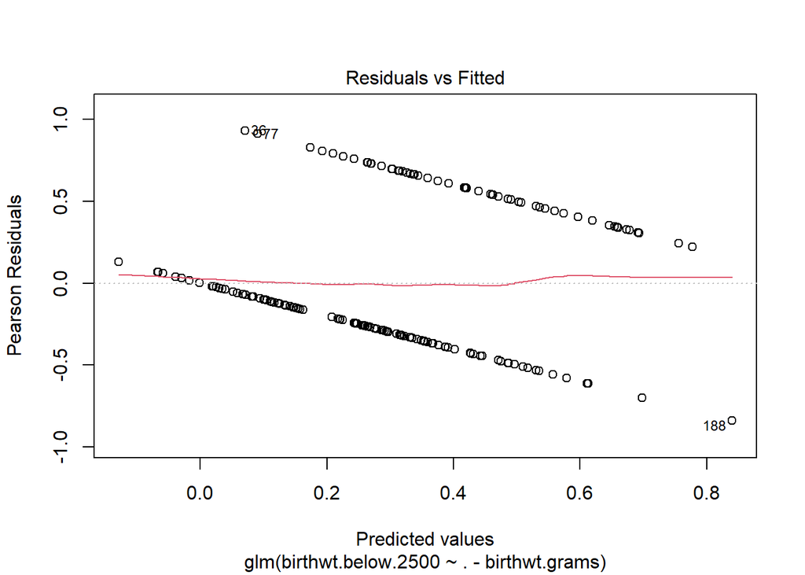

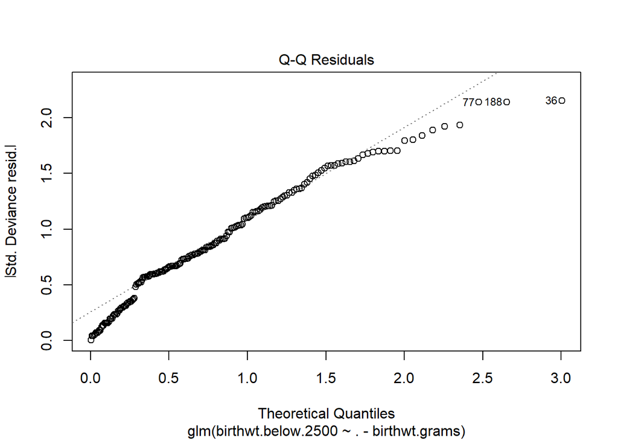

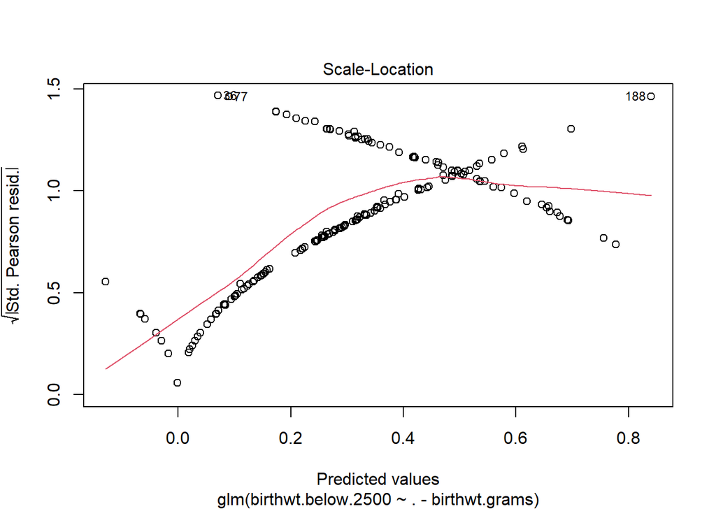

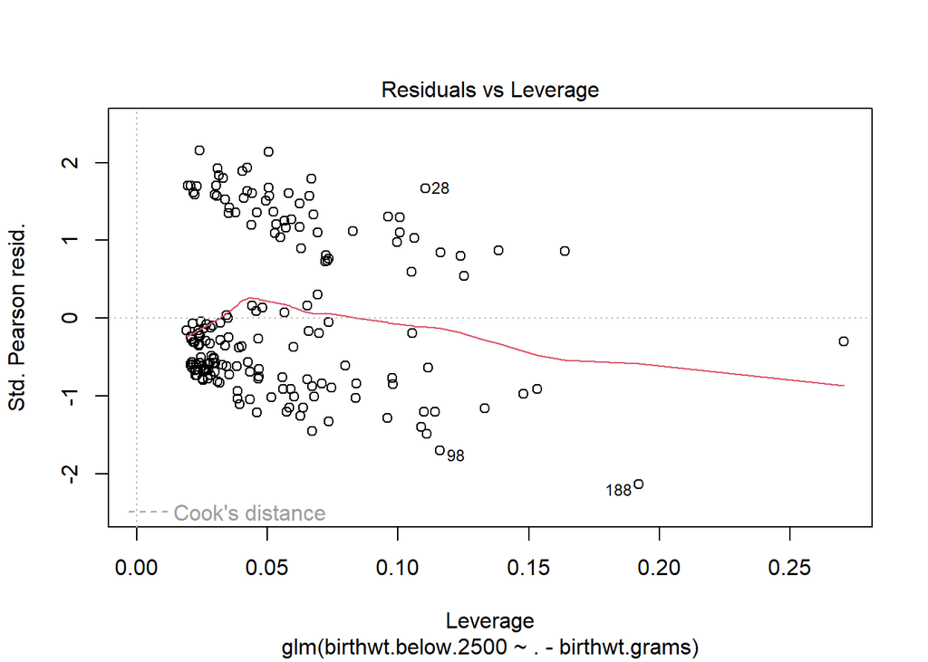

```r
plot(glm.0)
```

The default value is a Gaussian model (a standard linear model). Change this:

```r
glm.1 <- glm (birthwt.below.2500 ~ . - birthwt.grams, data=birthwt.noout, family=binomial(link=logit))
summary(glm.1)
```

```
##
## Call:
## glm(formula = birthwt.below.2500 ~ . - birthwt.grams, family = binomial(link = logit),
##     data = birthwt.noout)
##
## Coefficients:
##                      Estimate Std. Error z value Pr(>|z|)
## (Intercept)          1.721830   1.258897   1.368  0.17140
## mother.age          -0.027537   0.037718  -0.730  0.46534
## mother.weight       -0.015474   0.006919  -2.237  0.02532 *
## raceother           -0.395505   0.537685  -0.736  0.46199
## racewhite           -1.269006   0.527180  -2.407  0.01608 *
## mother.smokesYes     0.931733   0.402359   2.316  0.02058 *
## previous.prem.labor  0.539549   0.345413   1.562  0.11828
## hypertensionYes      1.860521   0.697502   2.667  0.00764 **
## uterine.irrYes       0.766517   0.458951   1.670  0.09489 .
## physician.visits     0.063402   0.172431   0.368  0.71310
## ---
## Signif. codes:  0 '***' 0.001 '**' 0.01 '*' 0.05 '.' 0.1 ' ' 1
##
## (Dispersion parameter for binomial family taken to be 1)
##
##     Null deviance: 233.92  on 187  degrees of freedom
## Residual deviance: 201.15  on 178  degrees of freedom
## AIC: 221.15
##
## Number of Fisher Scoring iterations: 4
```